# Anushka Nagpure_5A_Project 2_Time series analysis

```r
# # Required Packages
packages = c('quantmod','car','forecast','tseries','FinTS', 'rugarch','utf8','ggplot2')
#
# # Install all Packages with Dependencies
# install.packages(packages, dependencies = TRUE)
#
# # Load all Packages
lapply(packages, require, character.only = TRUE)
```

[output not shown]

```
[[1]]
[1] TRUE

[[2]]
[1] TRUE

[[3]]
[1] TRUE

[[4]]
[1] TRUE

[[5]]
[1] TRUE

[[6]]
[1] TRUE

[[7]]
[1] TRUE

[[8]]
[1] TRUE
```

```r
getSymbols(Symbols = 'ICICIBANK.NS',
           src = 'yahoo',
           from = as.Date('2018-01-01'),
           to = as.Date('2023-12-31'),
           periodicity = 'daily')
```

```
[1] "ICICIBANK.NS"
```

```r
ICICIBANK.NS_price = na.omit(ICICIBANK.NS$ICICIBANK.NS.Adjusted) # Adjusted Closing Price
class(ICICIBANK.NS_price) # xts (Time-Series) Object
```

```
[1] "xts" "zoo"
```

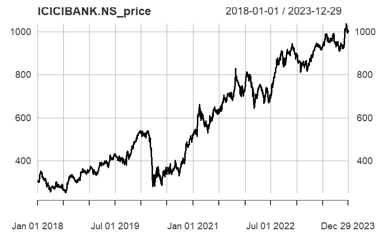

```r
ICICIBANK.NS_return = na.omit(diff(log(ICICIBANK.NS_price)));
plot(ICICIBANK.NS_price)
```

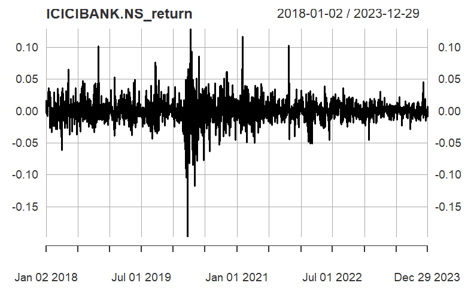

```r
plot(ICICIBANK.NS_return)
```

```r
#ADF test for Stationery

adf_test_jj = adf.test(ICICIBANK.NS_return); adf_test_jj
```

```
    Augmented Dickey-Fuller Test

data:  ICICIBANK.NS_return
Dickey-Fuller = -10.345, Lag order = 11, p-value = 0.01
alternative hypothesis: stationary
```

Analysis:

Objective: To conduct an Augmented Dickey-Fuller (ADF) test for stationarity on the daily returns of ICICI BANK stock. Analysis: Performed the ADF test using the ‘adf.test’ function and obtained results. Result: The Augmented Dickey-Fuller test for stationarity on ICICI BANK daily returns yields the following results: - Dickey-Fuller statistic: -10.345 - Lag order: 11 - p-value: 0.01 - Alternative hypothesis: Stationary

Implication: The ADF test suggests that the daily returns of ICICI BANK stock are likely stationary. The small p-value (0.01) indicates evidence against the null hypothesis of non-stationarity. Therefore, we have reason to believe that the ICICI BANK stock returns exhibit stationarity, which is important for certain time series analyses.

```r
#Autocorrelation test
# Ljung-Box Test for Autocorrelation
lb_test_ds = Box.test(ICICIBANK.NS_return); lb_test_ds
```

```
    Box-Pierce test

data:  ICICIBANK.NS_return
X-squared = 1.9756, df = 1, p-value = 0.1599
```

```r
#If autocorrelation exists then autoARIMA
```

Analysis:

Objective: To perform a Ljung-Box test for autocorrelation on the daily returns of ICICI BANK stock. Analysis: Conducted the Ljung-Box test using the ‘Box.test’ function and obtained results. Result: The Ljung-Box test for autocorrelation on ICICI BANK daily returns yields the following results: - X-squared statistic: 1.9756 - Degrees of freedom: 1 - p-value: 0.1599

Action: Given that there is no presence of autocorrelation, it may be advisable to not to consider an autoARIMA model for time series forecasting.

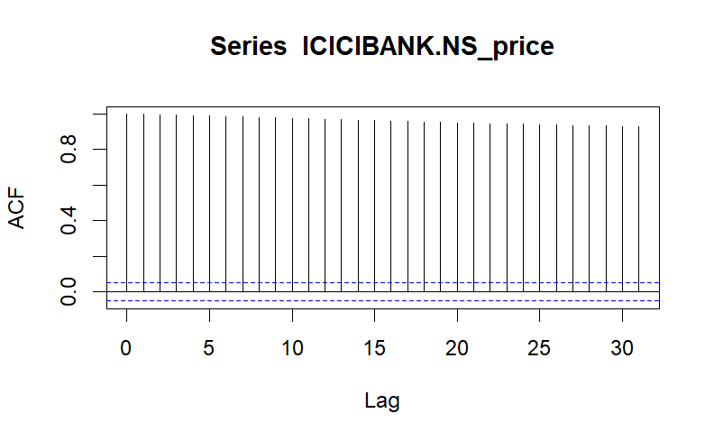

```r
#ACF and PCF

acf(ICICIBANK.NS_price) # ACF of JJ Series
```

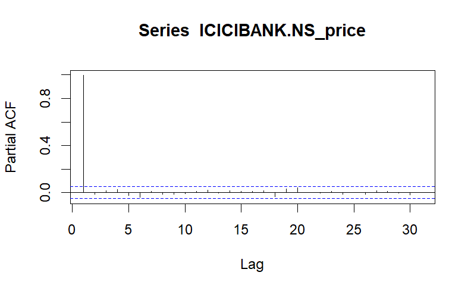

```r
pacf(ICICIBANK.NS_price) # PACF of JJ Series
```

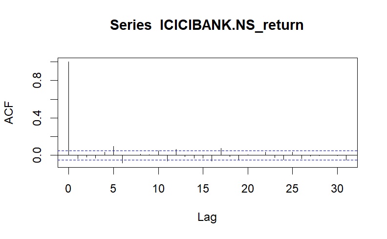

```r
acf(ICICIBANK.NS_return) # ACF of JJ Difference (Stationary) Series
```

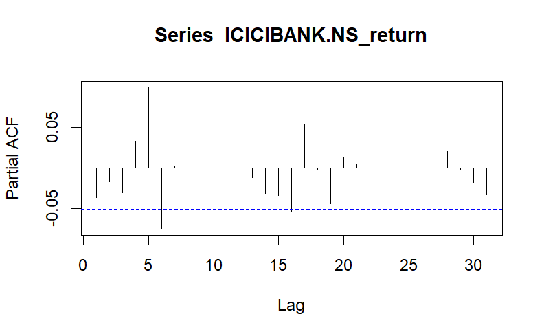

```r
pacf(ICICIBANK.NS_return) # PACF of JJ Difference (Stationary) Series
```

```r
NA
NA
```

```r
#AutoArima
arma_pq_ds = auto.arima(ICICIBANK.NS_return); arma_pq_ds
```

```
Series: ICICIBANK.NS_return
ARIMA(3,0,2) with non-zero mean

Coefficients:
          ar1      ar2      ar3      ma1     ma2   mean
      -0.0095  -0.8631  -0.0789  -0.0295  0.8354  8e-04
s.e.   0.0999   0.0550   0.0287   0.0979  0.0617  5e-04

sigma^2 = 0.0004207:  log likelihood = 3655.33
AIC=-7296.66   AICc=-7296.58   BIC=-7259.56
```

```r
arma_pq = auto.arima(ICICIBANK.NS_price); arma_pq
```

```
Series: ICICIBANK.NS_price
ARIMA(2,1,3) with drift

Coefficients:
          ar1      ar2     ma1     ma2      ma3   drift
      -0.4150  -0.7048  0.4275  0.7008  -0.0671  0.4720
s.e.   0.1306   0.1775  0.1322  0.1856   0.0345  0.2516

sigma^2 = 99.47:  log likelihood = -5500.98
AIC=11015.97   AICc=11016.04   BIC=11053.06
```

Note: Although there is no autocorrelation in ICICI BANK returns data; for academic understanding purpose, I have executed the code. Analysis:

Objective: To perform autoARIMA modeling on the daily returns (‘ICICIBANK_return’) and adjusted closing prices (‘ICICIBANK_price’) of ICICI BANK stock.

Implication: The autoARIMA models provide a statistical framework to capture the underlying patterns in both daily returns and adjusted closing prices of ICICI BANK stock. These models can be used for forecasting future values, and the AIC, AICc, and BIC values help in model comparison.

Note: Interpretation of the coefficients and model selection details may require further analysis based on the specific context of the financial data.

```r
#Arima manuplation
arma13 = arima(ICICIBANK.NS_return, order = c(3, 0, 2)); arma13
```

```
Call:
arima(x = ICICIBANK.NS_return, order = c(3, 0, 2))

Coefficients:
          ar1      ar2      ar3      ma1     ma2  intercept
      -0.0095  -0.8631  -0.0789  -0.0295  0.8354      8e-04
s.e.   0.0999   0.0550   0.0287   0.0979  0.0617      5e-04

sigma^2 estimated as 0.000419:  log likelihood = 3655.33,  aic = -7296.66
```

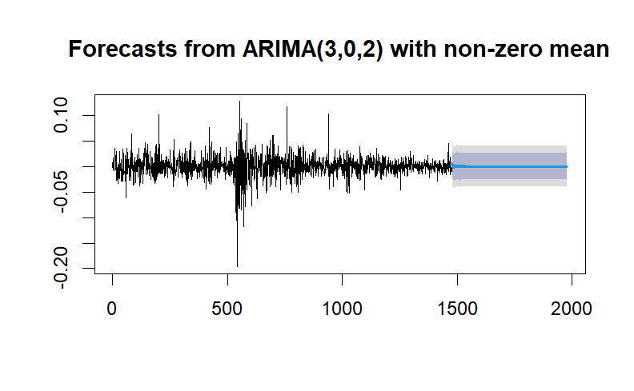

```r
ds_fpq = forecast(arma13, h = 500)
plot(ds_fpq)
```

Analysis:

Objective: To fit an ARIMA(3,0,2) model to the daily returns (‘ICICIBANK.NS_return’) of ICICI BANK stock and generate forecasts. Analysis: Used the ‘arima’ function to fit the ARIMA model and the ‘forecast’ function to generate forecasts. Results:

Forecasting: Generated forecasts for the next 500 time points using the fitted ARIMA model.

Plot: The plot displays the original time series of daily returns along with the forecasted values.

Implication: The ARIMA(3,0,2) model is fitted to the historical daily returns of ICICI BANK stock, providing insights into the underlying patterns. The generated forecast can be used for future predictions, and the plot visually represents the model’s performance.

Note: Interpretation of coefficients and model evaluation details may require further analysis based on the specific context of the financial data.

```r
#Autocorrelation test
# Ljung-Box Test for Autocorrelation
lb_test_ds_A = Box.test(arma13$residuals); lb_test_ds_A
```

```
    Box-Pierce test

data:  arma13$residuals
X-squared = 0.0053342, df = 1, p-value = 0.9418
```

```r
#After this no autocorrelation exists
```

Analysis:

Objective: To perform a Ljung-Box test for autocorrelation on the residuals of the ARIMA(3, 0, 2) model. Analysis: Conducted the Ljung-Box test using the ‘Box.test’ function on the residuals of the ARIMA model and obtained results. Results:

Implication: The Ljung-Box test indicates no significant autocorrelation in the residuals of the ARIMA(3, 0, 2) model. The high p-value (0.9418) suggests that there is no evidence against the null hypothesis of no autocorrelation.

Action: The absence of autocorrelation in residuals is a positive outcome, indicating that the ARIMA model adequately captures the temporal patterns in the time series.

Note: Interpretation may vary based on the specific context of the financial data and the assumptions underlying the time series analysis.

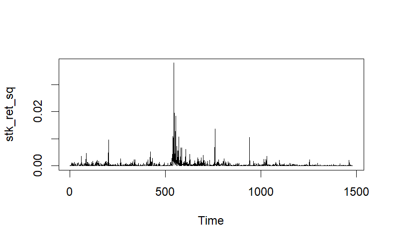

```r
# Test for Volatility Clustering or Heteroskedasticity: Box Test
stk_ret_sq = arma13$residuals^2 # Return Variance (Since Mean Returns is approx. 0)
plot(stk_ret_sq)
```

```r
stk_ret_sq_box_test = Box.test(stk_ret_sq, lag = 11) # H0: Return Variance Series is Not Serially Correlated
stk_ret_sq_box_test # Inference : Return Variance Series is Heteroskedastic (Has Volatility Clustering)
```

```
    Box-Pierce test

data:  stk_ret_sq
X-squared = 577.36, df = 11, p-value < 2.2e-16
```

```r
# Test for Volatility Clustering or Heteroskedasticity: ARCH Test
stk_ret_arch_test = ArchTest(arma13$residuals, lags = 11) # H0: No ARCH Effects
stk_ret_arch_test # Inference : Return Series is Heteroskedastic (Has Volatility Clustering)
```

```
    ARCH LM-test; Null hypothesis: no ARCH effects

data:  arma13$residuals
Chi-squared = 263.94, df = 11, p-value < 2.2e-16
```

Analysis: Objective: To test for volatility clustering or heteroskedasticity in the residuals of the ARIMA(3, 0, 2) model. Analysis: Conducted Box test and ARCH test on the squared residuals to assess the presence of volatility clustering. Results:

1. Box Test for Volatility Clustering:
- X-squared statistic: 577.36
- Degrees of freedom: 11
- p-value < 2.2e-16 Inference: The Box test indicates significant evidence against the null hypothesis, suggesting that the return variance series exhibits volatility clustering or heteroskedasticity.
2. ARCH Test for Volatility Clustering:
   - Chi-squared statistic: 263.94
   - Degrees of freedom: 11
   - p-value: < 2.2e-16 Inference: The ARCH test also provides strong evidence against the null hypothesis, supporting the presence of ARCH effects in the return series. This implies that the returns have volatility clustering.

Implication: The results from both tests suggest that the residuals of the ARIMA(3, 0, 2) model exhibit volatility clustering or heteroskedasticity. Understanding and accounting for this pattern in volatility is essential for risk management and forecasting.

Note: Interpretation may vary based on the specific context of the financial data and the assumptions underlying the time series analysis.

```r
#Garch model
garch_model1 = ugarchspec(variance.model = list(model = 'sGARCH', garchOrder = c(1,1)), mean.model = list(armaOrder = c(3,2), include.mean = TRUE))
nse_ret_garch1 = ugarchfit(garch_model1, data = arma13$residuals); nse_ret_garch1
```

```
*---------------------------------*
*          GARCH Model Fit        *
*---------------------------------*

Conditional Variance Dynamics
-----------------------------------
GARCH Model : sGARCH(1,1)
Mean Model  : ARFIMA(3,0,2)
Distribution    : norm

Optimal Parameters
------------------------------------
        Estimate  Std. Error  t value Pr(>|t|)
mu      0.000132    0.000413  0.31943 0.749399
ar1    -0.004423    0.162017 -0.02730 0.978221
ar2     0.789467    0.139120  5.67470 0.000000
ar3    -0.061197    0.026174 -2.33807 0.019383
ma1     0.075175    0.166582  0.45128 0.651791
ma2    -0.790203    0.177426 -4.45370 0.000008
omega   0.000007    0.000005  1.48846 0.136629
alpha1  0.107020    0.018185  5.88500 0.000000
beta1   0.880426    0.015126 58.20644 0.000000

Robust Standard Errors:
        Estimate  Std. Error   t value Pr(>|t|)
mu      0.000132    0.000493  0.267355 0.789196
ar1    -0.004423    0.138162 -0.032013 0.974461
ar2     0.789467    0.128224  6.156936 0.000000
ar3    -0.061197    0.030071 -2.035076 0.041843
ma1     0.075175    0.132918  0.565572 0.571685
ma2    -0.790203    0.129504 -6.101752 0.000000
omega   0.000007    0.000020  0.346597 0.728894
alpha1  0.107020    0.058768  1.821043 0.068600
beta1   0.880426    0.028514 30.877007 0.000000

LogLikelihood : 3893.023

Information Criteria
------------------------------------

```

[output cut: 34 more lines]

```
ar1    0.4315
ar2    0.2689
ar3    0.1518
ma1    0.4465
ma2    0.2761
omega  0.5294
alpha1 0.2776
beta1  0.2841

Asymptotic Critical Values (10% 5% 1%)
Joint Statistic:         2.1 2.32 2.82
Individual Statistic:    0.35 0.47 0.75

Sign Bias Test
------------------------------------
```

|  | t-value | prob | sig |
| --- | --- | --- | --- |
| Sign Bias | 0.8111487 | 0.4174111 |  |
| Negative Sign Bias | 0.5746613 | 0.5656080 |  |
| Positive Sign Bias | 0.9608035 | 0.3368085 |  |
| Joint Effect | 1.2606609 | 0.7384951 |  |

```
Adjusted Pearson Goodness-of-Fit Test:
------------------------------------
  group statistic p-value(g-1)
1    20     38.81     0.004673
2    30     47.49     0.016605
3    40     55.51     0.041840
4    50     61.35     0.110838


Elapsed time : 0.751529
```

```r
garch_model2 = ugarchspec(variance.model = list(model = 'sGARCH', garchOrder = c(1,1)), mean.model = list(armaOrder = c(3,2), include.mean = FALSE))
nse_ret_garch2 = ugarchfit(garch_model2, data = arma13$residuals); nse_ret_garch2
```

```
*---------------------------------*
*          GARCH Model Fit        *
*---------------------------------*

Conditional Variance Dynamics
-----------------------------------
GARCH Model : sGARCH(1,1)
Mean Model  : ARFIMA(3,0,2)
Distribution    : norm

Optimal Parameters
------------------------------------
        Estimate  Std. Error    t value Pr(>|t|)
ar1    -1.386494    0.000536 -2585.6002  0.00000
ar2    -0.923910    0.004242  -217.8019  0.00000
ar3     0.049428    0.004611    10.7196  0.00000
ma1     1.442884    0.000456  3161.2838  0.00000
ma2     0.999736    0.000217  4614.6352  0.00000
omega   0.000007    0.000005     1.4119  0.15799
alpha1  0.107316    0.018259     5.8775  0.00000
beta1   0.879484    0.015937    55.1854  0.00000

Robust Standard Errors:
        Estimate  Std. Error    t value Pr(>|t|)
ar1    -1.386494    0.005967 -232.35173 0.000000
ar2    -0.923910    0.008710 -106.07157 0.000000
ar3     0.049428    0.010382    4.76096 0.000002
ma1     1.442884    0.001526  945.80702 0.000000
ma2     0.999736    0.000584 1711.08852 0.000000
omega   0.000007    0.000023    0.30894 0.757368
alpha1  0.107316    0.062320    1.72202 0.085067
beta1   0.879484    0.035751   24.60018 0.000000

LogLikelihood : 3896.269

Information Criteria
------------------------------------

Akaike       -5.2544
Bayes        -5.2258
```

[output cut: 31 more lines]

```
ar1    0.01559
ar2    0.35874
ar3    0.62918
ma1    0.02482
ma2    0.10924
omega  0.58501
alpha1 0.29884
beta1  0.31756

Asymptotic Critical Values (10% 5% 1%)
Joint Statistic:         1.89 2.11 2.59
Individual Statistic:    0.35 0.47 0.75

Sign Bias Test
------------------------------------
```

|  | t-value | prob | sig |
| --- | --- | --- | --- |
| Sign Bias | 0.6903824 | 0.4900624 |  |
| Negative Sign Bias | 0.5095792 | 0.6104225 |  |
| Positive Sign Bias | 0.8135227 | 0.4160497 |  |
| Joint Effect | 0.9257973 | 0.8191983 |  |

```
Adjusted Pearson Goodness-of-Fit Test:
------------------------------------
  group statistic p-value(g-1)
1    20     43.16     0.001232
2    30     51.91     0.005585
3    40     59.89     0.017313
4    50     89.19     0.000395


Elapsed time : 1.242362
```

```r
# Test for Volatility Clustering or Heteroskedasticity: ARCH Test
gar_resd = residuals(nse_ret_garch2)^2
stk_ret_arch_test1 = ArchTest(gar_resd, lags = 11) # H0: No ARCH Effects
stk_ret_arch_test1 # Inference : Return Series is Heteroskedastic (Has Volatility Clustering)
```

```
    ARCH LM-test; Null hypothesis: no ARCH effects

data:  gar_resd
Chi-squared = 101.77, df = 11, p-value < 2.2e-16
```

Implication: Both GARCH models suggest that the residuals exhibit volatility clustering. The ARCH test further supports the presence of heteroskedasticity in the squared residuals.

Note: Interpretation may vary based on the specific context of the financial data and the assumptions underlying the time series analysis.

```r
garch_modelf = ugarchspec(variance.model = list(model = 'sGARCH', garchOrder = c(1,1)), mean.model = list(armaOrder = c(3,2), include.mean = FALSE))
stk_ret_garch = ugarchfit(garch_modelf, data = ICICIBANK.NS_return); stk_ret_garch
```

```
*---------------------------------*
*          GARCH Model Fit        *
*---------------------------------*

Conditional Variance Dynamics
-----------------------------------
GARCH Model : sGARCH(1,1)
Mean Model  : ARFIMA(3,0,2)
Distribution    : norm

Optimal Parameters
------------------------------------
        Estimate  Std. Error  t value Pr(>|t|)
ar1    -0.168436    0.404006 -0.41691 0.676742
ar2    -0.437268    0.241389 -1.81147 0.070068
ar3    -0.045099    0.035703 -1.26317 0.206527
ma1     0.207495    0.403900  0.51373 0.607442
ma2     0.412172    0.247328  1.66650 0.095614
omega   0.000007    0.000004  1.59773 0.110104
alpha1  0.110440    0.017913  6.16550 0.000000
beta1   0.877837    0.015542 56.48123 0.000000

Robust Standard Errors:
        Estimate  Std. Error  t value Pr(>|t|)
ar1    -0.168436    0.491802 -0.34249 0.731985
ar2    -0.437268    0.214023 -2.04309 0.041044
ar3    -0.045099    0.037016 -1.21836 0.223087
ma1     0.207495    0.493835  0.42017 0.674361
ma2     0.412172    0.226379  1.82072 0.068650
omega   0.000007    0.000015  0.44549 0.655964
alpha1  0.110440    0.045641  2.41974 0.015532
beta1   0.877837    0.026478 33.15309 0.000000

LogLikelihood : 3894.68

Information Criteria
------------------------------------

Akaike       -5.2523
Bayes        -5.2236
```

[output cut: 31 more lines]

```
ar1    0.31122
ar2    0.06629
ar3    0.19305
ma1    0.31315
ma2    0.04954
omega  0.57742
alpha1 0.27856
beta1  0.29759

Asymptotic Critical Values (10% 5% 1%)
Joint Statistic:         1.89 2.11 2.59
Individual Statistic:    0.35 0.47 0.75

Sign Bias Test
------------------------------------
```

|  | t-value | prob | sig |
| --- | --- | --- | --- |
| Sign Bias | 0.3774322 | 0.7059068 |  |
| Negative Sign Bias | 0.4548857 | 0.6492584 |  |
| Positive Sign Bias | 0.7083887 | 0.4788158 |  |
| Joint Effect | 0.7735246 | 0.8557886 |  |

```
Adjusted Pearson Goodness-of-Fit Test:
------------------------------------
  group statistic p-value(g-1)
1    20     40.38     0.002918
2    30     51.95     0.005527
3    40     58.38     0.023716
4    50     69.19     0.030241


Elapsed time : 0.6400328
```

Analysis:

Note: Interpretation may vary based on the specific context of the financial data and the assumptions underlying the time series analysis.

```r
# GARCH Forecast
stk_ret_garch_forecast1 = ugarchforecast(stk_ret_garch, n.ahead = 50); stk_ret_garch_forecast1
```

```
*------------------------------------*
*       GARCH Model Forecast         *
*------------------------------------*
Model: sGARCH
Horizon: 50
Roll Steps: 0
Out of Sample: 0

0-roll forecast [T0=2023-12-29]:
         Series   Sigma
T+1  -1.003e-03 0.01173
T+2   4.248e-04 0.01195
T+3   7.858e-04 0.01216
T+4  -2.729e-04 0.01236
T+5  -3.168e-04 0.01256
T+6   1.372e-04 0.01275
T+7   1.277e-04 0.01294
T+8  -6.724e-05 0.01313
T+9  -5.071e-05 0.01331
T+10  3.218e-05 0.01348
T+11  1.979e-05 0.01365
T+12 -1.512e-05 0.01382
T+13 -7.557e-06 0.01398
T+14  6.991e-06 0.01414
T+15  2.809e-06 0.01429
T+16 -3.189e-06 0.01444
T+17 -1.006e-06 0.01459
T+18  1.437e-06 0.01474
T+19  3.417e-07 0.01488
T+20 -6.407e-07 0.01502
T+21 -1.063e-07 0.01515
T+22  2.827e-07 0.01529
T+23  2.778e-08 0.01542
T+24 -1.235e-07 0.01555
T+25 -4.098e-09 0.01567
T+26  5.343e-08 0.01579
T+27 -1.639e-09 0.01592
T+28 -2.290e-08 0.01603
T+29  2.165e-09 0.01615
T+30  9.724e-09 0.01626
T+31 -1.551e-09 0.01638
T+32 -4.088e-09 0.01649
T+33  9.285e-10 0.01659
T+34  1.701e-09 0.01670
T+35 -5.082e-10 0.01680
T+36 -7.002e-10 0.01691
T+37  2.634e-10 0.01701
T+38  2.847e-10 0.01710
T+39 -1.316e-10 0.01720
T+40 -1.142e-10 0.01730
T+41  6.393e-11 0.01739
T+42  4.511e-11 0.01748
T+43 -3.040e-11 0.01757
T+44 -1.749e-11 0.01766
T+45  1.420e-11 0.01775
T+46  6.625e-12 0.01783
T+47 -6.538e-12 0.01792
T+48 -2.436e-12 0.01800
T+49  2.971e-12 0.01808
T+50  8.598e-13 0.01816
```

Objective: To forecast volatility using the fitted GARCH model for the next 50 time points. Analysis: Used the ‘ugarchforecast’ function to generate volatility forecasts for the next 50 time points. Results:

GARCH Model Forecast: - Model: sGARCH - Horizon: 50 - Roll Steps: 0 - Out of Sample: 0

Implication: The forecasted values represent the predicted volatility for the next 50 time points based on the fitted GARCH model. These forecasts can be useful for risk management and decision-making, providing insights into the expected future volatility of the financial time series.

```r
plot(stk_ret_garch_forecast1)
```

```
Make a plot selection (or 0 to exit):

1:   Time Series Prediction (unconditional)
2:   Time Series Prediction (rolling)
3:   Sigma Prediction (unconditional)
4:   Sigma Prediction (rolling)
```

```r
1
```

```
Make a plot selection (or 0 to exit):

1:   Time Series Prediction (unconditional)
2:   Time Series Prediction (rolling)
3:   Sigma Prediction (unconditional)
4:   Sigma Prediction (rolling)
```

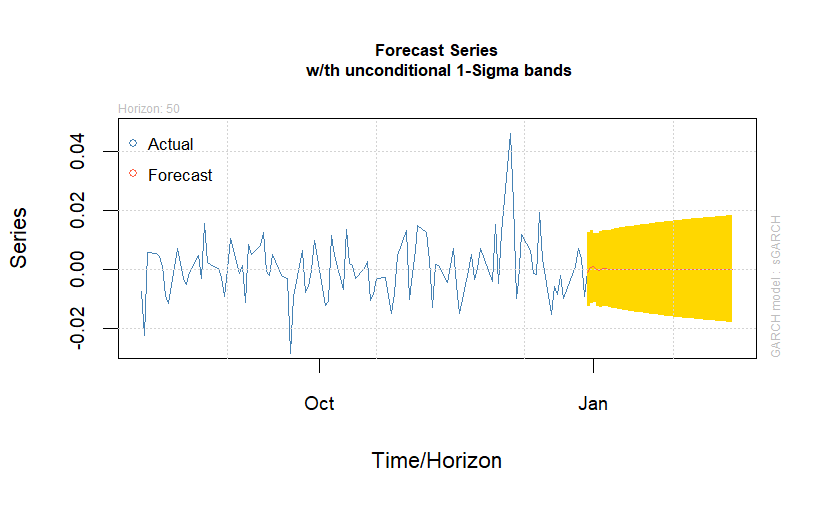

```
Make a plot selection (or 0 to exit):

1:   Time Series Prediction (unconditional)
2:   Time Series Prediction (rolling)
3:   Sigma Prediction (unconditional)
4:   Sigma Prediction (rolling)
```

```r
3
```

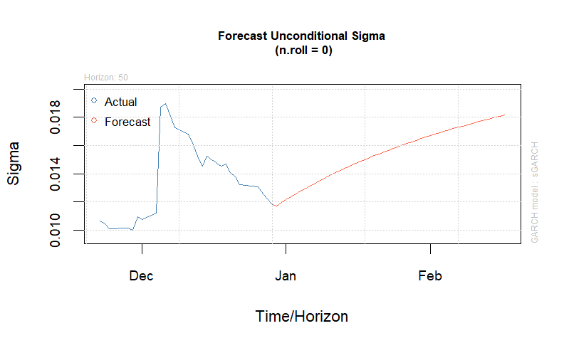

```r
0
```